# Data Science Project - A Review of the Relationship Between Song Features and Its Relative Popularity With Respect to Time

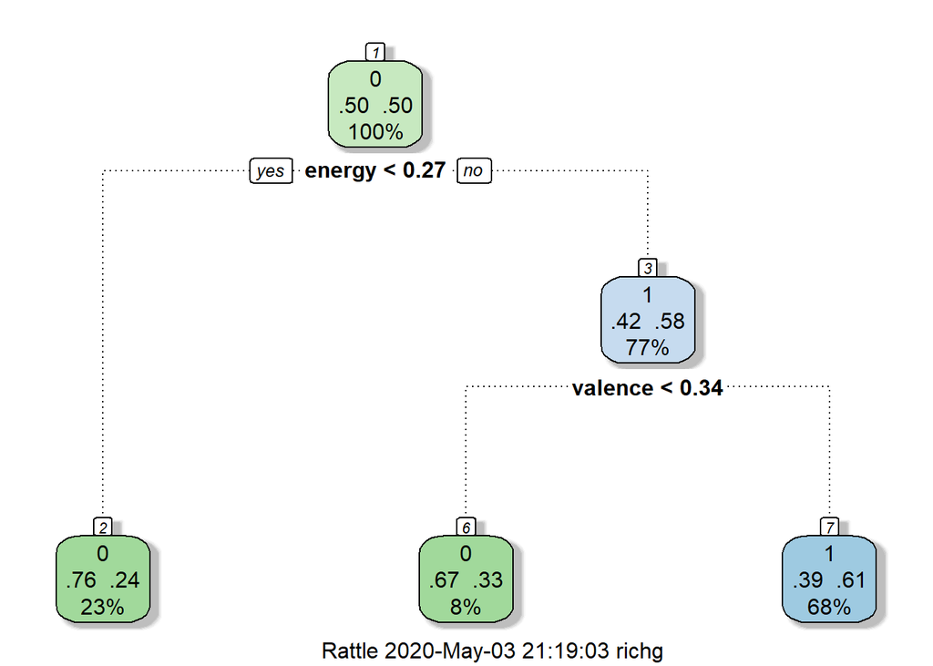

```r
loadPkg("rattle") # For fancyRpartPlot (Trees) Answer "no" on installing from binary source
fancyRpartPlot(data1960_DT)
```

2000’s Song Fancy and Rpart Plots

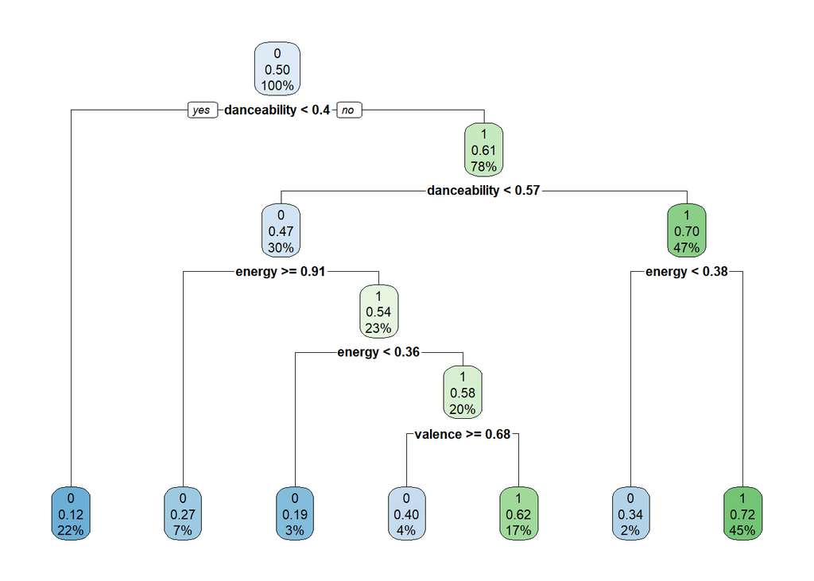

```r
rpart.plot(data2000_DT)
```

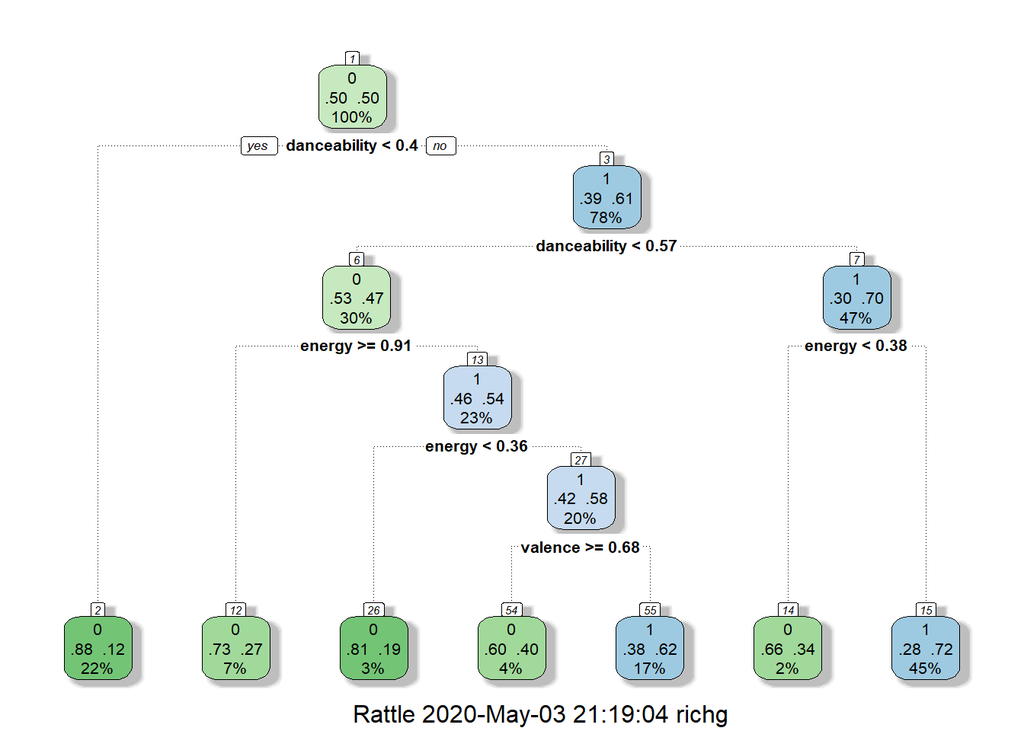

```r
fancyRpartPlot(data2000_DT)
```

## 11.2 Prune the tree

We can now prune the decision trees to get the most important results to know what variables are most important to be put onto the Billboard’s Top 100 list. The following are from the pruning of the trees:

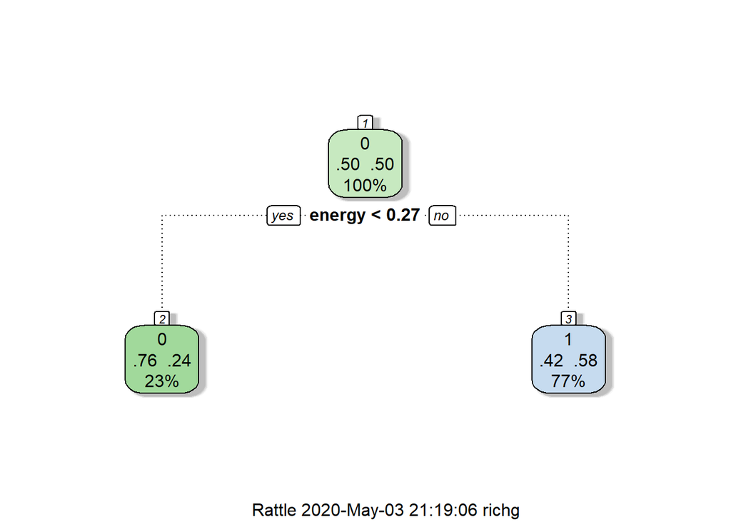

```r
#prune the tree
PT_data1960_DT <- prune(data1960_DT, cp = data1960_DT$cptable[2,"CP"])
#pkyphosisfit <- prune(kyphosisfit, cp = kyphosisfit$cptable[which.min( kyphosisfit$cptable[,"xerror"] ),"CP"])
# plot the pruned tree
fancyRpartPlot(PT_data1960_DT)
```

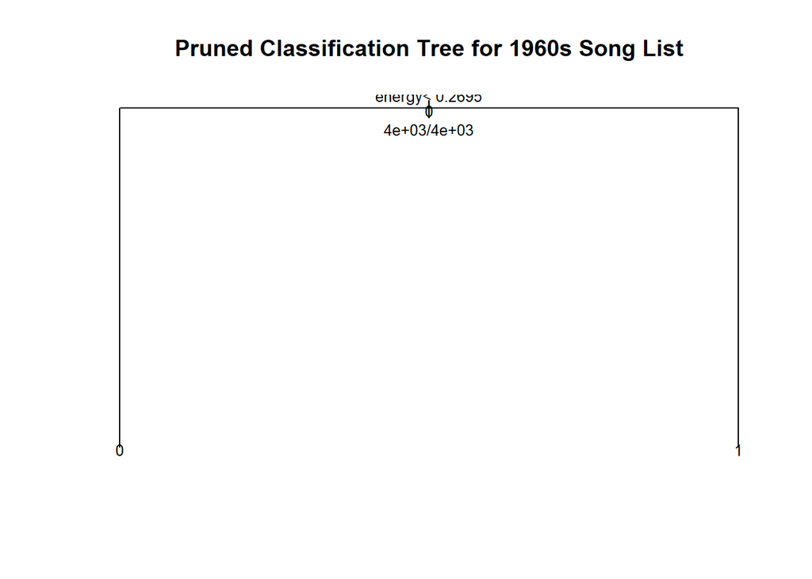

```r
# For boring plot, use codes below instead
plot(PT_data1960_DT, uniform=TRUE, main="Pruned Classification Tree for 1960s Song List")
text(PT_data1960_DT, use.n=TRUE, all=TRUE, cex=.8)
```

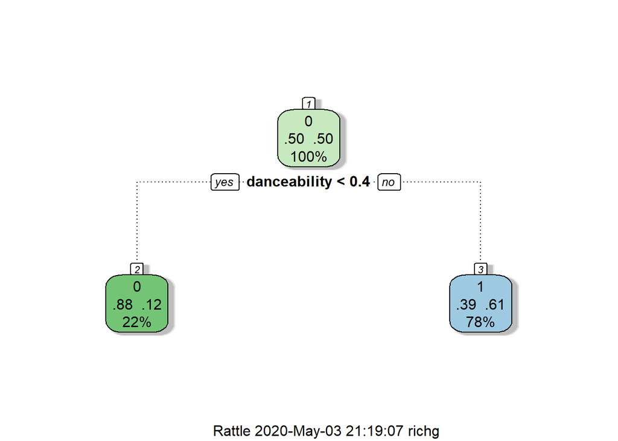

```r
#prune the tree
PT_data2000_DT <- prune(data2000_DT, cp = data2000_DT$cptable[2,"CP"])
#pkyphosisfit <- prune(kyphosisfit, cp = kyphosisfit$cptable[which.min( kyphosisfit$cptable[,"xerror"] ),"CP"])
# plot the pruned tree
fancyRpartPlot(PT_data2000_DT)
```

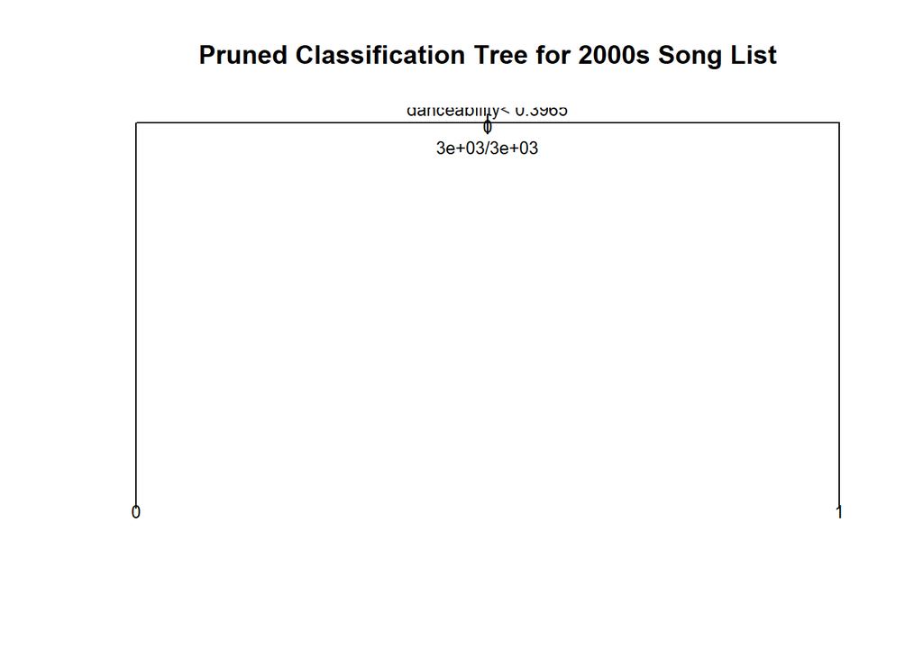

```r
# For boring plot, use codes below instead
plot(PT_data2000_DT, uniform=TRUE, main="Pruned Classification Tree for 2000s Song List")
text(PT_data2000_DT, use.n=TRUE, all=TRUE, cex=.8)
```

From the pruned trees, the results show different variables for each year on what classified them to get on the Billboard’s Top 100 List. For the 1960’s songs, the song needed to have an energy level greater than 0.27. This is shown as the most significant variable that determines the popularity of a song. In order for a song in the 2000’s to make the list, the danceability matters more than energy. The dancebility had to be greater than a level of 0.40. In the two eras, there were differences in what was deemed as most important. In the 1960’s, a person needed to have the right energy being exuded from the music, while in the 2000’s the song had to be a danceable song.

# 12 Logit Regression - Siwei

```r
data1960$track <- factor(data1960$track)
data1960$artist <- factor(data1960$artist)
data1960$key <- factor(data1960$key)
data1960$mode <- factor(data1960$mode)
data1960$target <- factor(data1960$target)
```

```r
data1960Logit_1 <- glm(target ~ tempo, data = data1960, family = "binomial")
data1960Logit_1
```

```
##
## Call:  glm(formula = target ~ tempo, family = "binomial", data = data1960)
##
## Coefficients:
## (Intercept)        tempo
##    -0.99191      0.00862
##
## Degrees of Freedom: 8641 Total (i.e. Null);  8640 Residual
## Null Deviance:       12000
## Residual Deviance: 11800     AIC: 11900
```

We can see the summary of the logit model here:

```r
summary(data1960Logit_1)
```

```
##
## Call:
## glm(formula = target ~ tempo, family = "binomial", data = data1960)
##
## Deviance Residuals:
##     Min       1Q   Median       3Q      Max
## -1.5502  -1.1515  -0.0647   1.1724   1.6170
##
## Coefficients:
##              Estimate Std. Error z value Pr(>|z|)
## (Intercept) -0.991914   0.089406   -11.1   <2e-16 ***
## tempo        0.008623   0.000755    11.4   <2e-16 ***
## ---
## Signif. codes:  0 '***' 0.001 '**' 0.01 '*' 0.05 '.' 0.1 ' ' 1
##
## (Dispersion parameter for binomial family taken to be 1)
##
##     Null deviance: 11980  on 8641  degrees of freedom
## Residual deviance: 11847  on 8640  degrees of freedom
## AIC: 11851
##
## Number of Fisher Scoring iterations: 4
```

```r
data1960Logit_2 <- glm(target ~ tempo+valence, data = data1960, family = "binomial")
data1960Logit_2
```

```
##
## Call:  glm(formula = target ~ tempo + valence, family = "binomial",
##     data = data1960)
##
## Coefficients:
## (Intercept)        tempo      valence
##      -1.887        0.004        2.466
##
## Degrees of Freedom: 8641 Total (i.e. Null);  8639 Residual
## Null Deviance:       12000
## Residual Deviance: 11000     AIC: 11000
```

```r
summary(data1960Logit_2)
```

```
##
## Call:
## glm(formula = target ~ tempo + valence, family = "binomial",
##     data = data1960)
##
## Deviance Residuals:
##     Min       1Q   Median       3Q      Max
## -1.7599  -1.0767   0.0508   1.0470   2.0140
##
## Coefficients:
##              Estimate Std. Error z value Pr(>|z|)
## (Intercept) -1.887008   0.100356  -18.80  < 2e-16 ***
## tempo        0.004004   0.000804    4.98  6.3e-07 ***
## valence      2.465927   0.089806   27.46  < 2e-16 ***
## ---
## Signif. codes:  0 '***' 0.001 '**' 0.01 '*' 0.05 '.' 0.1 ' ' 1
##
## (Dispersion parameter for binomial family taken to be 1)
##
##     Null deviance: 11980  on 8641  degrees of freedom
## Residual deviance: 11015  on 8639  degrees of freedom
## AIC: 11021
##
## Number of Fisher Scoring iterations: 4
```

```r
data1960Logit_3 <- glm(target ~ tempo+valence+danceability, data = data1960, family = "binomial")
data1960Logit_3
```

```
##
## Call:  glm(formula = target ~ tempo + valence + danceability, family = "binomial",
##     data = data1960)
##
## Coefficients:
##  (Intercept)         tempo       valence  danceability
##     -2.15302       0.00456       2.16387       0.75989
##
## Degrees of Freedom: 8641 Total (i.e. Null);  8638 Residual
## Null Deviance:       12000
## Residual Deviance: 11000     AIC: 11000
```

```r
summary(data1960Logit_3)
```

```
##
## Call:
## glm(formula = target ~ tempo + valence + danceability, family = "binomial",
##     data = data1960)
##
## Deviance Residuals:
##    Min      1Q  Median      3Q     Max
## -1.728  -1.081   0.062   1.045   2.127
##
## Coefficients:
##               Estimate Std. Error z value Pr(>|z|)
## (Intercept)  -2.153017   0.121170  -17.77  < 2e-16 ***
## tempo         0.004562   0.000815    5.60  2.2e-08 ***
## valence       2.163874   0.116844   18.52  < 2e-16 ***
## danceability  0.759886   0.190395    3.99  6.6e-05 ***
## ---
## Signif. codes:  0 '***' 0.001 '**' 0.01 '*' 0.05 '.' 0.1 ' ' 1
##
## (Dispersion parameter for binomial family taken to be 1)
##
##     Null deviance: 11980  on 8641  degrees of freedom
## Residual deviance: 10999  on 8638  degrees of freedom
## AIC: 11007
##
## Number of Fisher Scoring iterations: 4
```

```r
data1960Logit_4 <- glm(target ~ tempo+valence+danceability+energy, data = data1960, family = "binomial")
data1960Logit_4
```

```
##
## Call:  glm(formula = target ~ tempo + valence + danceability + energy,
##     family = "binomial", data = data1960)
##
## Coefficients:
##  (Intercept)         tempo       valence  danceability        energy
##       -2.434         0.004         1.266         1.057         1.606
##
## Degrees of Freedom: 8641 Total (i.e. Null);  8637 Residual
## Null Deviance:       12000
## Residual Deviance: 10900     AIC: 10900
```

```r
summary(data1960Logit_4)
```

```
##
## Call:
## glm(formula = target ~ tempo + valence + danceability + energy,
##     family = "binomial", data = data1960)
##
## Deviance Residuals:
##     Min       1Q   Median       3Q      Max
## -1.9208  -1.0611   0.0588   1.0304   1.9885
##
## Coefficients:
##               Estimate Std. Error z value Pr(>|z|)
## (Intercept)  -2.433755   0.125096  -19.46  < 2e-16 ***
## tempo         0.003997   0.000823    4.85  1.2e-06 ***
## valence       1.266002   0.139391    9.08  < 2e-16 ***
## danceability  1.057094   0.193712    5.46  4.8e-08 ***
## energy        1.606477   0.137452   11.69  < 2e-16 ***
## ---
## Signif. codes:  0 '***' 0.001 '**' 0.01 '*' 0.05 '.' 0.1 ' ' 1
##
## (Dispersion parameter for binomial family taken to be 1)
##
##     Null deviance: 11980  on 8641  degrees of freedom
## Residual deviance: 10860  on 8637  degrees of freedom
## AIC: 10870
##
## Number of Fisher Scoring iterations: 4
```

The best model for year 1960 is data1960Logit_4. All the coefficients are found significant because of the small p-values. Tempo, valence, danceability and energy all have positive effects on music popularity. Energy had the biggest positive coefficient on music in 1960, while tempo had the smallest influence on popularity.```

```r
x = exp(coef(data1960Logit_4))
x
```

```
##  (Intercept)        tempo      valence danceability       energy
##       0.0877       1.0040       3.5466       2.8780       4.9852
```

```r
data1960Logit_4$fitted.values[1]
```

```
##     1
## 0.693
```

```r
predict(data1960Logit_4)[1]
```

```
##     1
## 0.815
```

```r
1/(1+exp(-predict(data1960Logit_4)[1]))
```

```
##     1
## 0.693
```

```r
data1960Logit_5 <- glm(target ~ tempo+valence+danceability+energy+liveness, data = data1960, family = "binomial")
data1960Logit_5
```

```
##
## Call:  glm(formula = target ~ tempo + valence + danceability + energy +
##     liveness, family = "binomial", data = data1960)
##
## Coefficients:
##  (Intercept)         tempo       valence  danceability        energy
##     -2.45193       0.00401       1.26192       1.07071       1.59839
##     liveness
##      0.07146
##
## Degrees of Freedom: 8641 Total (i.e. Null);  8636 Residual
## Null Deviance:       12000
## Residual Deviance: 10900     AIC: 10900
```

```r
summary(data1960Logit_5)
```

```
##
## Call:
## glm(formula = target ~ tempo + valence + danceability + energy +
##     liveness, family = "binomial", data = data1960)
##
## Deviance Residuals:
##     Min       1Q   Median       3Q      Max
## -1.9160  -1.0610   0.0596   1.0303   1.9857
##
## Coefficients:
##               Estimate Std. Error z value Pr(>|z|)
## (Intercept)  -2.451931   0.129908  -18.87  < 2e-16 ***
## tempo         0.004014   0.000824    4.87  1.1e-06 ***
## valence       1.261924   0.139611    9.04  < 2e-16 ***
## danceability  1.070710   0.195469    5.48  4.3e-08 ***
## energy        1.598389   0.138319   11.56  < 2e-16 ***
## liveness      0.071464   0.136936    0.52      0.6
## ---
## Signif. codes:  0 '***' 0.001 '**' 0.01 '*' 0.05 '.' 0.1 ' ' 1
##
## (Dispersion parameter for binomial family taken to be 1)
##
##     Null deviance: 11980  on 8641  degrees of freedom
## Residual deviance: 10860  on 8636  degrees of freedom
## AIC: 10872
##
## Number of Fisher Scoring iterations: 4
```